# Business Statistics End of Term Assessment IB94X0

2243694

This is to certify that the work I am submitting is my own. All external references and sources are clearly acknowledged and identified within the contents. I am aware of the University of Warwick regulation concerning plagiarism and collusion.

No substantial part(s) of the work submitted here has also been submitted by me in other assessments for accredited courses of study, and I acknowledge that if this has been done an appropriate reduction in the mark I might otherwise have received will be made

```r
library(tidyverse)
library(ggplot2)
library(emmeans)
library(gridExtra)
library(Hmisc)
library(car)
library(corrplot)
```

## Question 1

### Objective

#### * Understand Bike Hire Usage Trends

#### * Assess the Impact of COVID-19 Measures

#### * Control for Temporal Variations

#### * Explore Interaction Effects

| Variable | Description |
| --- | --- |
| Hires | Number of bike hires |
| schools_closed | Schools closed during covid period |
| pubs_closed | Pubs closed during covid period |
| shops_closed | Shops closed during covid period |
| eating_places_closed | Eating places closed during covid period |
| stay_at_home | Stay at home orders |
| household_mixing_indoors_banned | Prohibits individuals from different households coming together and socializing inside a private residence |
| wfh | Work from Home |
| rule_of_6_indoors | Maximum indoors gathering limit to six individuals |
| curfew | Activities and movements are restricted |
| eat_out_to_help_out | Encourage people to dine outside by offering discounts on meals |

```r
#Loading dataset
dataset_bikes<-read.csv("London_COVID_bikes.csv")
```

## Data Preprocessing

```r
#the dataset provide priority of labels for months in alphabetical order so to change those and converting each dataset attribute into a factor
custom_month_labels <- c("Jan","Feb","Mar","Apr", "May", "Jun","Jul", "Aug","Sep","Oct","Nov","Dec")
dataset_bikes$month <- factor(dataset_bikes$month, levels = custom_month_labels)
```

```r
custom_day_labels <- c("Sun","Mon", "Tue", "Wed", "Thu", "Fri", "Sat")
dataset_bikes$day <- factor(dataset_bikes$day, levels = custom_day_labels)
```

```r
# Check data structure
summary(dataset_bikes)
```

```
##      date               Hires       schools_closed     pubs_closed
##  Length:4812        Min.   :    0   Min.   :0.00000   Min.   :0.00000
##  Class :character   1st Qu.:19776   1st Qu.:0.00000   1st Qu.:0.00000
##  Mode  :character   Median :26356   Median :0.00000   Median :0.00000
##                     Mean   :26607   Mean   :0.02743   Mean   :0.05175
##                     3rd Qu.:33481   3rd Qu.:0.00000   3rd Qu.:0.00000
##                     Max.   :73094   Max.   :1.00000   Max.   :1.00000
##
##   shops_closed     eating_places_closed  stay_at_home
##  Min.   :0.00000   Min.   :0.00000      Min.   :0.00000
##  1st Qu.:0.00000   1st Qu.:0.00000      1st Qu.:0.00000
##  Median :0.00000   Median :0.00000      Median :0.00000
##  Mean   :0.04634   Mean   :0.05175      Mean   :0.03616
##  3rd Qu.:0.00000   3rd Qu.:0.00000      3rd Qu.:0.00000
##  Max.   :1.00000   Max.   :1.00000      Max.   :1.00000
##
##  household_mixing_indoors_banned      wfh         rule_of_6_indoors
##  Min.   :0.00000                 Min.   :0.0000   Min.   :0.00000
##  1st Qu.:0.00000                 1st Qu.:0.0000   1st Qu.:0.00000
##  Median :0.00000                 Median :0.0000   Median :0.00000
##  Mean   :0.06525                 Mean   :0.2273   Mean   :0.01995
##  3rd Qu.:0.00000                 3rd Qu.:0.0000   3rd Qu.:0.00000
##  Max.   :1.00000                 Max.   :1.0000   Max.   :1.00000
##
##      curfew        eat_out_to_help_out  day          month           year
##  Min.   :0.00000   Min.   :0.000000    Sun:687   Aug    : 434   Min.   :2010
##  1st Qu.:0.00000   1st Qu.:0.000000    Mon:688   Sep    : 420   1st Qu.:2013
##  Median :0.00000   Median :0.000000    Tue:687   Jul    : 405   Median :2017
##  Mean   :0.01164   Mean   :0.005819    Wed:687   Dec    : 404   Mean   :2017
##  3rd Qu.:0.00000   3rd Qu.:0.000000    Thu:687   Jan    : 403   3rd Qu.:2020
##  Max.   :1.00000   Max.   :1.000000    Fri:688   Mar    : 403   Max.   :2023
##                                        Sat:688   (Other):2343
```

```r
str(dataset_bikes)
```

```
## 'data.frame':    4812 obs. of  15 variables:
##  $ date                           : chr  "2010-07-30" "2010-07-31" "2010-08-01" "2010-08-02" ...
##  $ Hires                          : int  6897 5564 4303 6642 7966 7893 8724 9797 6631 7864 ...
##  $ schools_closed                 : int  0 0 0 0 0 0 0 0 0 0 ...
##  $ pubs_closed                    : int  0 0 0 0 0 0 0 0 0 0 ...
##  $ shops_closed                   : int  0 0 0 0 0 0 0 0 0 0 ...
##  $ eating_places_closed           : int  0 0 0 0 0 0 0 0 0 0 ...
##  $ stay_at_home                   : int  0 0 0 0 0 0 0 0 0 0 ...
##  $ household_mixing_indoors_banned: int  0 0 0 0 0 0 0 0 0 0 ...
##  $ wfh                            : int  0 0 0 0 0 0 0 0 0 0 ...
##  $ rule_of_6_indoors              : int  0 0 0 0 0 0 0 0 0 0 ...
##  $ curfew                         : int  0 0 0 0 0 0 0 0 0 0 ...
##  $ eat_out_to_help_out            : int  0 0 0 0 0 0 0 0 0 0 ...
##  $ day                            : Factor w/ 7 levels "Sun","Mon","Tue",..: 6 7 1 2 3 4 5 6 7 1 ...
##  $ month                          : Factor w/ 12 levels "Jan","Feb","Mar",..: 7 7 8 8 8 8 8 8 8 8 ...
##  $ year                           : int  2010 2010 2010 2010 2010 2010 2010 2010 2010 2010 ...
```

```r
#Checking Null values
sum(is.na(dataset_bikes))
```

```
## [1] 0
```

```r
#Remove duplicate records if any
dataset_bikes<-unique(dataset_bikes)
```

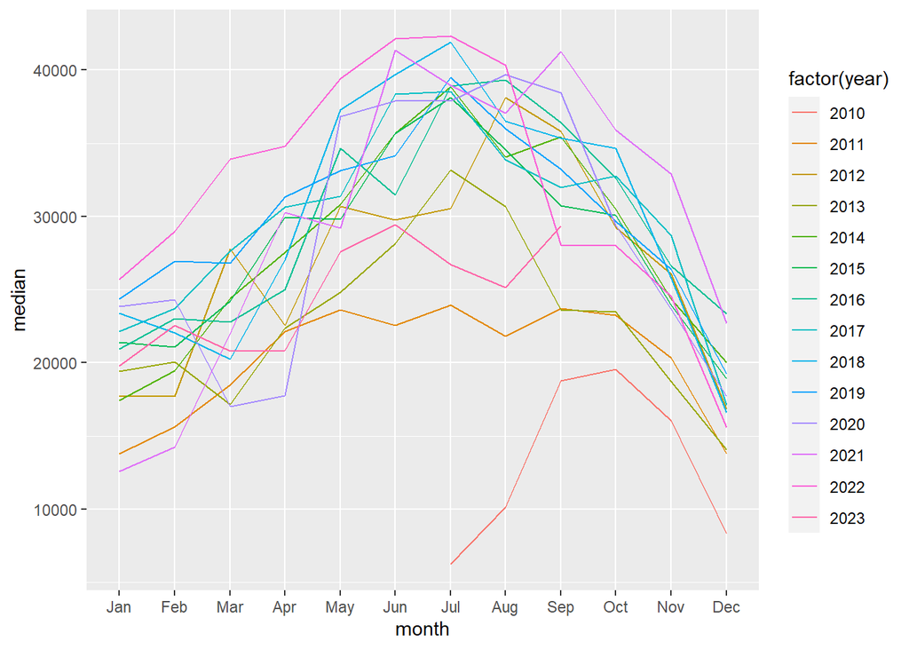

```r
# Plotting the data
dataset_median<-dataset_bikes%>%
  group_by(year,month)%>%
  dplyr::summarize(median= median(Hires))
ggplot(dataset_median)+geom_line(aes(x=month,y=median,group=factor(year),color=factor(year)))
```

We can Clearly see that the overall the number of hires are maximum for the month of June July and Aug in addition to this the data for 2010 and 2023 are not complete so we can easily remove those years. Also we have to measure the effect of covid measures on bike hires so we have to take the years that are significant for us which are from 2017 to 2021

```r
dataset_bikes<-dataset_bikes %>%
  dplyr::filter(year %in% c(2017,2018,2019,2020,2021,2021))
```

## Time Wise plotting

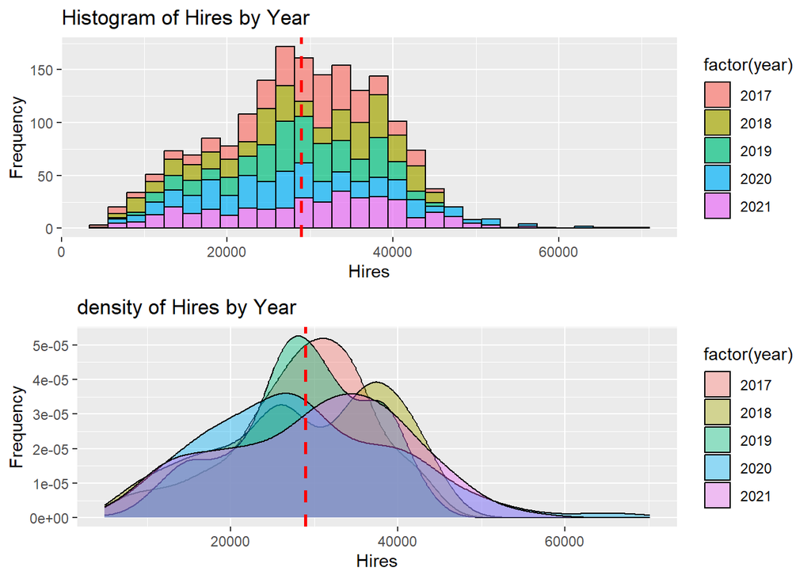

```r
#plotting the data

plot1<-ggplot(dataset_bikes, aes(x = Hires, fill = factor(year))) +
  geom_histogram(alpha = 0.7, bins = 30,color="black",position = "stack")  +
  geom_vline(xintercept = mean(dataset_bikes$Hires), linetype = "dashed", color = "red", linewidth = 1) +
  labs(title = "Histogram of Hires by Year",
       x = "Hires",
       y = "Frequency")
plot2<-ggplot(dataset_bikes, aes(x = Hires, fill = factor(year))) +
  geom_density(alpha = 0.4,color="black")  +
  geom_vline(xintercept = mean(dataset_bikes$Hires), linetype = "dashed", color = "red", linewidth = 1) +
  labs(title = "density of Hires by Year",
       x = "Hires",
       y = "Frequency")
grid.arrange(plot1,plot2)
```

The graphs shows a normal distribution of the data over the years and the red dotted line shows the average number of hires across the year and the whole of the distribution shows a normal distribution of data

### checking for outliers

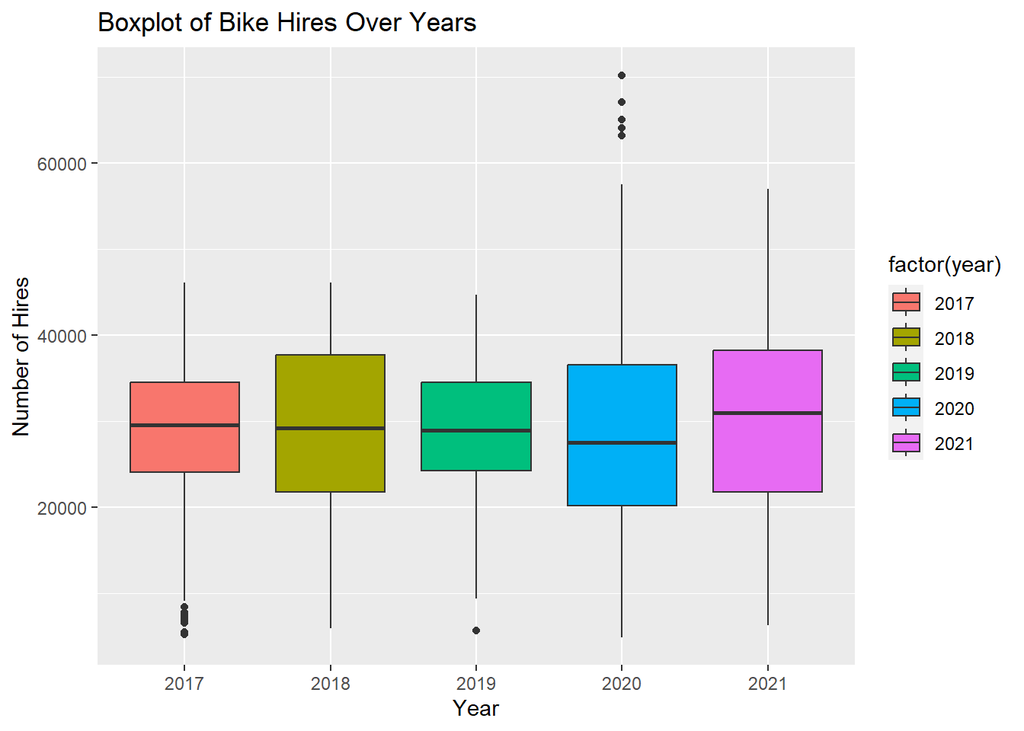

```r
ggplot(dataset_bikes)+geom_boxplot(aes(x=factor(year),y=Hires,fill=factor(year))) +  labs(title = "Boxplot of Bike Hires Over Years",
       x = "Year",
       y = "Number of Hires")
```

```r
#removing outliers
threshold <-1.5
data_clean<- dataset_bikes %>%
  group_by(year) %>%
  filter(Hires >= quantile(Hires, 0.25) - threshold * IQR(Hires),
         Hires <= quantile(Hires, 0.75) + threshold * IQR(Hires))

dataset_bikes<-data_clean
```

### The outliers have been removed now

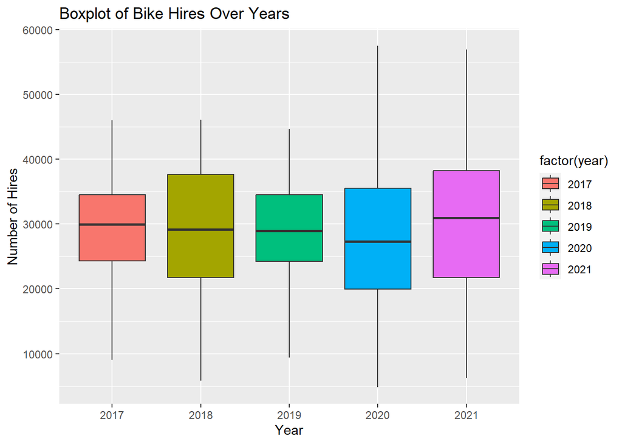

```r
ggplot(data_clean)+geom_boxplot(aes(x=factor(year),y=Hires,fill=factor(year))) +  labs(title = "Boxplot of Bike Hires Over Years",
       x = "Year",
       y = "Number of Hires")
```

### Year wise Analysis for number of hires

```r
hires_lm <- lm(Hires~factor(year),data=dataset_bikes)
```

```r
dataset_emm <- emmeans(hires_lm,~.factor(year))
emmvar <- emmeans(hires_lm,~factor(year))
contrast <- confint(pairs(dataset_emm))
```

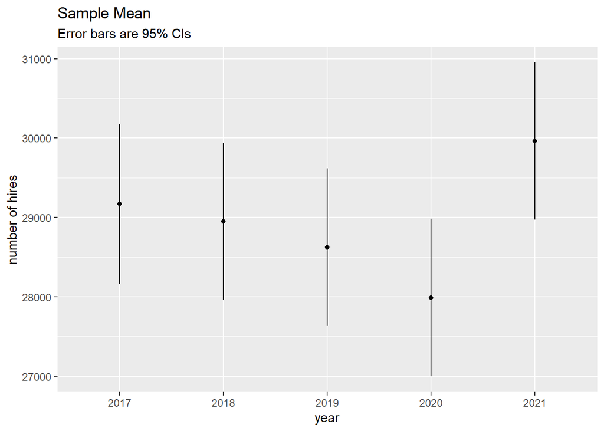

```r
ggplot(summary(emmvar), aes(x=factor(year), y=emmean, ymin=lower.CL, ymax=upper.CL)) +
        geom_point() + geom_linerange() +
        labs(y="number of hires", x="year", subtitle="Error bars are 95% CIs", title="Sample Mean")
```

### Performing T-test

```r
t.test(data_clean$Hires[data_clean$year==2019],data_clean$Hires[data_clean$year==2021])
```

```
##
##  Welch Two Sample t-test
##
## data:  data_clean$Hires[data_clean$year == 2019] and data_clean$Hires[data_clean$year == 2021]
## t = -1.882, df = 667.85, p-value = 0.06027
## alternative hypothesis: true difference in means is not equal to 0
## 95 percent confidence interval:
##  -2734.25123    57.97218
## sample estimates:
## mean of x mean of y
##  28624.47  29962.61
```

The Welch Two Sample t-test compared the mean number of hires in 2019 and 2021, yielding a non-significant p-value of 0.06027. The 95% confidence interval ranged from -2734.25 to 57.97, suggesting no significant difference in means. While marginally significant, practical implications may require further investigation due to potential limitations.

###### Analysis For the year 2020 (when covid started)

```r
dataset_2020<-dataset_bikes%>%
  filter(year==2020)
dataset_2021<-dataset_bikes%>%
  filter(year==2021)
```

###### Analysis For the year 2020

```r
# The COVID started which resulted in this huge difference in the value of hires in year 2020 as compared to year 2019
t.test(data_clean$Hires[data_clean$year==2019&data_clean$month=="Mar"],data_clean$Hires[data_clean$year==2020&data_clean$month=="Mar"])
```

```
##
##  Welch Two Sample t-test
##
## data:  data_clean$Hires[data_clean$year == 2019 & data_clean$month == "Mar"] and data_clean$Hires[data_clean$year == 2020 & data_clean$month == "Mar"]
## t = 4.5879, df = 59.421, p-value = 2.363e-05
## alternative hypothesis: true difference in means is not equal to 0
## 95 percent confidence interval:
##   4340.809 11054.288
## sample estimates:
## mean of x mean of y
##  25557.16  17859.61
```

The t-test comparing March 2019 and March 2020 Hires data indicates a significant difference in means (p = 2.363e-05). The 95% confidence interval for the true difference in Hires between the two periods is [4340.809 11054.288]. The mean Hires in March 2019 (25557.16) is significantly higher than in March 2020 (17859.61 ), suggesting a notable decline in hiring

```r
#For year 2020
hires_lm_2020 <- lm(Hires~factor(month),data=dataset_2020)
emmvar_2020 <-  emmeans(hires_lm_2020,~.factor(month))
contrast_2020<-confint(pairs(emmvar_2020))
```

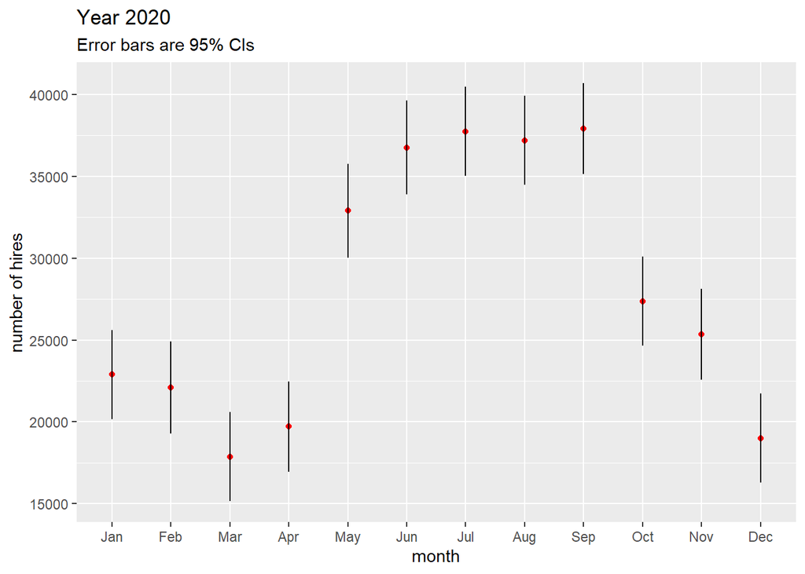

```r
 ggplot(summary(emmvar_2020), aes(x=factor(month), y=emmean, ymin=lower.CL, ymax=upper.CL)) +
        geom_point(color="red") + geom_linerange() +
        labs(y="number of hires", x="month", subtitle="Error bars are 95% CIs", title="Year 2020")
```

Bikes hires suddenly dropped from feb to march showing that the covid restrictions were enforced in march 2020.The graph also shows rapid increase in hires form April to May is the result of people are hiring more bike in may as compared to April. Also after the month of september the number of hires were decreased drastically indicating a sharp decrease in the hire from sept to oct for the year 2020 which shows the second wave of covid restrictions.

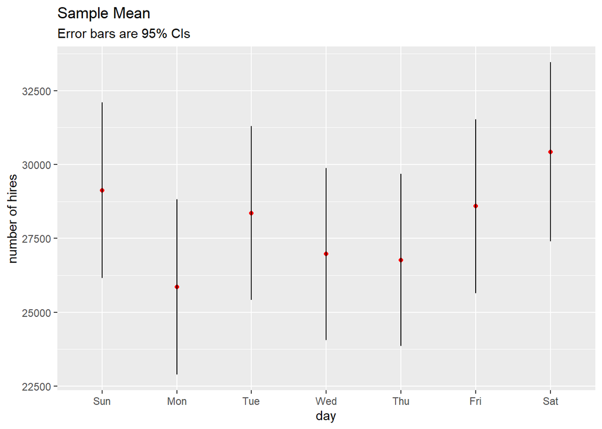

```r
hires_lm_days_2020 <- lm(Hires~factor(day),data=dataset_2020)
dataset_emm_days <- emmeans(hires_lm_days_2020,~.factor(day))
confint_hires_days<-confint(pairs(dataset_emm_days))

ggplot(summary(dataset_emm_days), aes(x=day, y=emmean, ymin=lower.CL, ymax=upper.CL)) +
        geom_point(color="red") + geom_linerange() +
        labs(y="number of hires", x="day", subtitle="Error bars are 95% CIs", title="Sample Mean")
```

The graph shows that the Saturday and Sunday have maximum number of hires as compared to rest of the days of the week for the year 2020

##### Analysis for year 2021

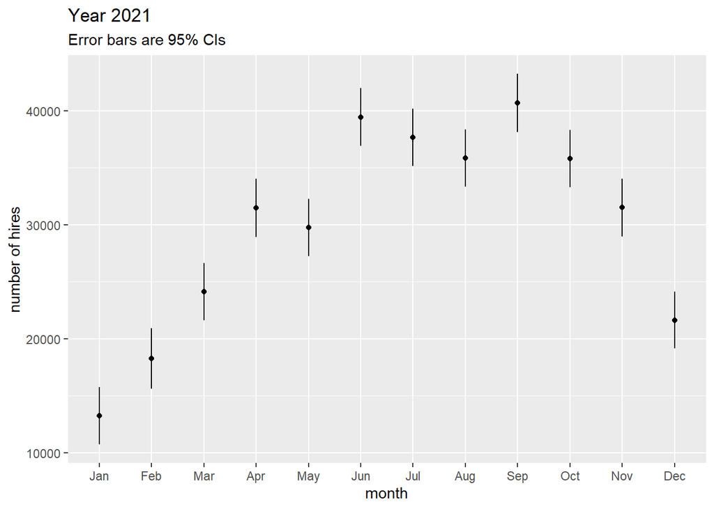

```r
hires_lm_2021 <- lm(Hires~factor(month),data=dataset_2021)
emmvar_2021 <-  emmeans(hires_lm_2021,~.factor(month))
contrast_2021<-confint(pairs(emmvar_2021))
ggplot(summary(emmvar_2021), aes(x=factor(month), y=emmean, ymin=lower.CL, ymax=upper.CL)) +
        geom_point() + geom_linerange() +
        labs(y="number of hires", x="month", subtitle="Error bars are 95% CIs", title="Year 2021")
```

the above graph shows that the year 2021 has normal trend as compared to 2020

##### Analysis After COVID-19 Measures

###### Correlation Analysis

```r
# Now for the effect of  Work From Home, Rule of 6 Indoors, and the Eat Out to Help Out scheme
dataset_post_covid<-dataset_bikes%>%
  filter(year>=2020)
dataset_pre_covid<-dataset_bikes%>%
  filter(year<2020)

# Correlation analysis for dataset after COVID-19 measures
dataset_corr <- as_tibble(dataset_post_covid)
(cor_matrix <- rcorr(as.matrix(select_if(dataset_corr,is.numeric))))
```

```
##                                 Hires schools_closed pubs_closed shops_closed
## Hires                            1.00          -0.37       -0.37        -0.40
## schools_closed                  -0.37           1.00        0.65         0.70
## pubs_closed                     -0.37           0.65        1.00         0.92
## shops_closed                    -0.40           0.70        0.92         1.00
## eating_places_closed            -0.37           0.65        1.00         0.92
## stay_at_home                    -0.50           0.67        0.79         0.85
## household_mixing_indoors_banned -0.36           0.53        0.81         0.76
## wfh                             -0.24           0.36        0.56         0.51
## rule_of_6_indoors                0.24          -0.18       -0.28        -0.26
## curfew                          -0.06          -0.13       -0.21        -0.19
## eat_out_to_help_out              0.14          -0.09       -0.14        -0.13
## year                             0.09          -0.02       -0.13        -0.06
##                                 eating_places_closed stay_at_home
## Hires                                          -0.37        -0.50
## schools_closed                                  0.65         0.67
## pubs_closed                                     1.00         0.79
## shops_closed                                    0.92         0.85
## eating_places_closed                            1.00         0.79
## stay_at_home                                    0.79         1.00
## household_mixing_indoors_banned                 0.81         0.65
## wfh                                             0.56         0.44
## rule_of_6_indoors                              -0.28        -0.22
## curfew                                         -0.21        -0.16
## eat_out_to_help_out                            -0.14        -0.11
## year                                           -0.13         0.00
##                                 household_mixing_indoors_banned   wfh
## Hires                                                     -0.36 -0.24
## schools_closed                                             0.53  0.36
## pubs_closed                                                0.81  0.56
## shops_closed                                               0.76  0.51
## eating_places_closed                                       0.81  0.56
## stay_at_home                                               0.65  0.44
## household_mixing_indoors_banned                            1.00  0.67
## wfh                                                        0.67  1.00
## rule_of_6_indoors                                         -0.34  0.24
## curfew                                                     0.10  0.23
## eat_out_to_help_out                                       -0.17 -0.26
## year                                                      -0.11 -0.05
##                                 rule_of_6_indoors curfew eat_out_to_help_out
```

[output cut: 80 more lines]

```
## eat_out_to_help_out             0.0353            0.1193
## year                            0.0013            0.0000 0.0000
##                                 year
## Hires                           0.0148
## schools_closed                  0.5683
## pubs_closed                     0.0006
## shops_closed                    0.1350
## eating_places_closed            0.0006
## stay_at_home                    0.9173
## household_mixing_indoors_banned 0.0033
## wfh                             0.1670
## rule_of_6_indoors               0.0013
## curfew                          0.0000
## eat_out_to_help_out             0.0000
## year
```

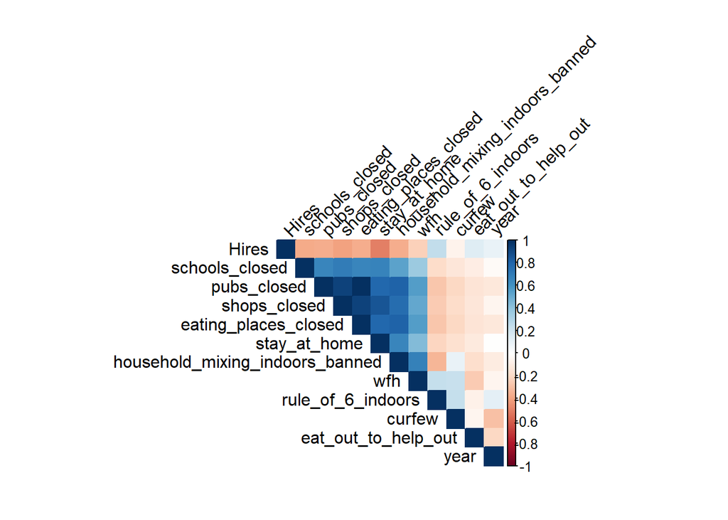

```r
corrplot(cor_matrix$r, method = "color", type = "upper", tl.col = "black", tl.srt = 45)
```

##### Correlation before covid-19 measures

```r
dataset_corr <- as_tibble(dataset_pre_covid)
(cor_matrix2<-rcorr(as.matrix(select_if(dataset_corr,is.numeric))))
```

```
##                                 Hires schools_closed pubs_closed shops_closed
## Hires                            1.00            NaN         NaN          NaN
## schools_closed                    NaN              1         NaN          NaN
## pubs_closed                       NaN            NaN           1          NaN
## shops_closed                      NaN            NaN         NaN            1
## eating_places_closed              NaN            NaN         NaN          NaN
## stay_at_home                      NaN            NaN         NaN          NaN
## household_mixing_indoors_banned   NaN            NaN         NaN          NaN
## wfh                               NaN            NaN         NaN          NaN
## rule_of_6_indoors                 NaN            NaN         NaN          NaN
## curfew                            NaN            NaN         NaN          NaN
## eat_out_to_help_out               NaN            NaN         NaN          NaN
## year                            -0.03            NaN         NaN          NaN
##                                 eating_places_closed stay_at_home
## Hires                                            NaN          NaN
## schools_closed                                   NaN          NaN
## pubs_closed                                      NaN          NaN
## shops_closed                                     NaN          NaN
## eating_places_closed                               1          NaN
## stay_at_home                                     NaN            1
## household_mixing_indoors_banned                  NaN          NaN
## wfh                                              NaN          NaN
## rule_of_6_indoors                                NaN          NaN
## curfew                                           NaN          NaN
## eat_out_to_help_out                              NaN          NaN
## year                                             NaN          NaN
##                                 household_mixing_indoors_banned wfh
## Hires                                                       NaN NaN
## schools_closed                                              NaN NaN
## pubs_closed                                                 NaN NaN
## shops_closed                                                NaN NaN
## eating_places_closed                                        NaN NaN
## stay_at_home                                                NaN NaN
## household_mixing_indoors_banned                               1 NaN
## wfh                                                         NaN   1
## rule_of_6_indoors                                           NaN NaN
## curfew                                                      NaN NaN
## eat_out_to_help_out                                         NaN NaN
## year                                                        NaN NaN
##                                 rule_of_6_indoors curfew eat_out_to_help_out
```

[output cut: 80 more lines]

```
## eat_out_to_help_out
## year
##                                 year
## Hires                           0.402
## schools_closed
## pubs_closed
## shops_closed
## eating_places_closed
## stay_at_home
## household_mixing_indoors_banned
## wfh
## rule_of_6_indoors
## curfew
## eat_out_to_help_out
## year
```

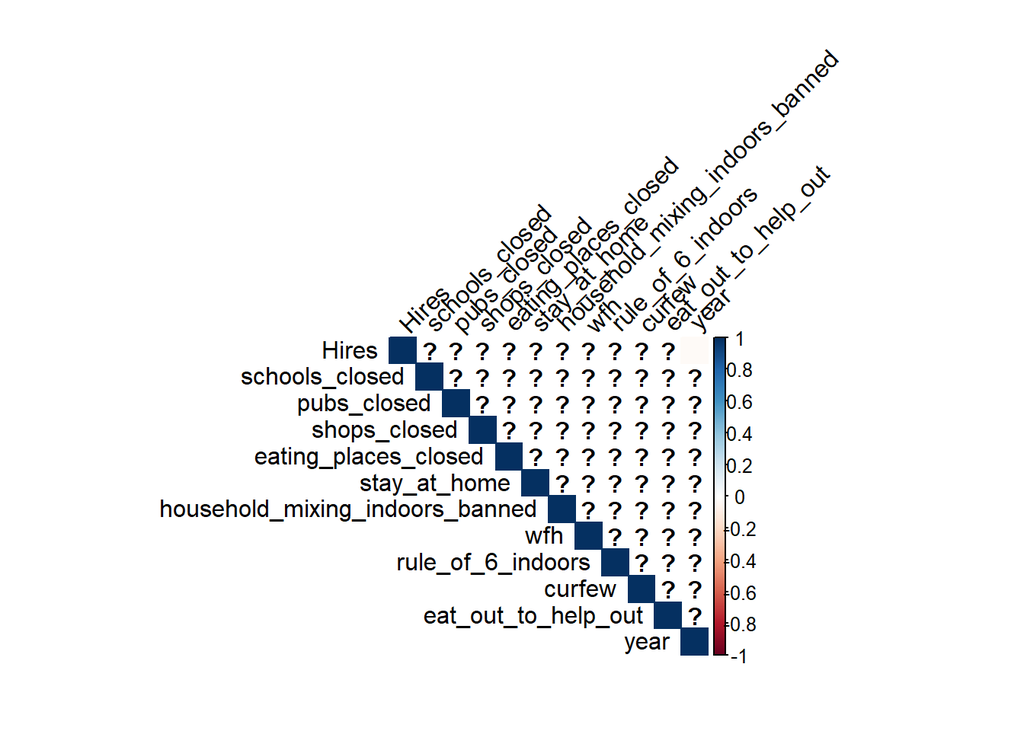

```r
corrplot(cor_matrix2$r, method = "color", type = "upper", tl.col = "black", tl.srt = 45)
```

#### Linear Models (lm)

```r
# Building linear models for dataset after COVID-19 measure
hire_lm_postcovid <- lm(Hires~year+month+day+wfh+eat_out_to_help_out+rule_of_6_indoors,data=dataset_post_covid)
hire_lm_postcovid2 <- lm(Hires~year*month*day*wfh*eat_out_to_help_out*rule_of_6_indoors,data=dataset_post_covid)
# anova test for model comparison
anova(hire_lm_postcovid,hire_lm_postcovid2)
```

```
## Analysis of Variance Table
##
## Model 1: Hires ~ year + month + day + wfh + eat_out_to_help_out + rule_of_6_indoors
## Model 2: Hires ~ year * month * day * wfh * eat_out_to_help_out * rule_of_6_indoors
##   Res.Df        RSS  Df  Sum of Sq     F    Pr(>F)
## 1    705 3.9497e+10
## 2    507 2.3928e+10 198 1.5568e+10 1.666 3.989e-06 ***
## ---
## Signif. codes:  0 '***' 0.001 '**' 0.01 '*' 0.05 '.' 0.1 ' ' 1
```

Our second model is more significantly different because lower p( < 3.989e-06) value and hence there are some interactions involved between wfh,eat_out_to_help_out,rule_of_6_indoors, year,month and day . The p-value is highly significant, suggesting there are some interactions involved. Therefore we can say that ‘wfh’, ‘rule of 6 indoors’ and ‘eat out to help out’ do have an effect on the bike hires.

```r
# making lm model for dataset before covid measures
hire_lm_precovid <- lm(Hires~year+month+day,data=dataset_pre_covid)
hire_lm_precovid2 <- lm(Hires~year*month*day,data=dataset_pre_covid)
anova(hire_lm_precovid,hire_lm_precovid2)
```

```
## Analysis of Variance Table
##
## Model 1: Hires ~ year + month + day
## Model 2: Hires ~ year * month * day
##   Res.Df        RSS  Df  Sum of Sq      F Pr(>F)
## 1   1066 3.2598e+10
## 2    917 2.8275e+10 149 4322509223 0.9408 0.6752
```

The p-value (0.6752) is greater than the typical significance level of 0.05. This suggests that the additional terms in Model 2 do not significantly improve the fit compared to Model 1 . Hence there are no interaction terms involved in the model.

####Checking results with VIF

```r
#now we have selected the model 1 from Pre covid measures and model2 from after covid measures
vif(hire_lm_precovid)
```

```
##           GVIF Df GVIF^(1/(2*Df))
## year  1.000536  1        1.000268
## month 1.005831 11        1.000264
## day   1.005567  6        1.000463
```

```r
vif(hire_lm_postcovid2,type="predictor")
```

```
## GVIFs computed for predictors
```

```
##                     GVIF   Df GVIF^(1/(2*Df))
## year                   1 1343               1
## month                  1 1343               1
## day                    1 1343               1
## wfh                    1 1343               1
## eat_out_to_help_out    1 1343               1
## rule_of_6_indoors      1 1343               1
##                                                               Interacts With
## year                 month, day, wfh, eat_out_to_help_out, rule_of_6_indoors
## month                 year, day, wfh, eat_out_to_help_out, rule_of_6_indoors
## day                 year, month, wfh, eat_out_to_help_out, rule_of_6_indoors
## wfh                 year, month, day, eat_out_to_help_out, rule_of_6_indoors
## eat_out_to_help_out                 year, month, day, wfh, rule_of_6_indoors
## rule_of_6_indoors                 year, month, day, wfh, eat_out_to_help_out
##                     Other Predictors
## year                            --
## month                           --
## day                             --
## wfh                             --
## eat_out_to_help_out             --
## rule_of_6_indoors               --
```

The GVIF scores for year month day wfh eat_out_to_help_out and rule_of_6_indoors are low between 1 and 5 , so these can be used in the same model and hence our both models can use these attributes as predictors.

#### Control for Days, Months and Years

we will have to check the control for the days month and years . For this we will make a foundation model and compare it with other models

```r
lm_base_model <- lm(Hires ~ wfh + rule_of_6_indoors + eat_out_to_help_out, dataset_post_covid)
```

this model will be used for further comparison for the effect of days month and years

```r
# model for seeing effect of  controlling days
lm_model_control_days <-lm(Hires ~ wfh + rule_of_6_indoors + eat_out_to_help_out+day, dataset_post_covid)

#model for seeing effect of controlling months
lm_model_control_month <-lm(Hires ~ wfh + rule_of_6_indoors + eat_out_to_help_out+month, dataset_post_covid)
# model for seeing effect of controlling years
lm_model_control_year <-lm(Hires ~ wfh + rule_of_6_indoors + eat_out_to_help_out+year, dataset_post_covid)
```

```r
# for effect of days
anova(lm_base_model,lm_model_control_days)
```

```
## Analysis of Variance Table
##
## Model 1: Hires ~ wfh + rule_of_6_indoors + eat_out_to_help_out
## Model 2: Hires ~ wfh + rule_of_6_indoors + eat_out_to_help_out + day
##   Res.Df        RSS Df  Sum of Sq      F   Pr(>F)
## 1    723 7.3087e+10
## 2    717 7.1176e+10  6 1911267921 3.2089 0.004076 **
## ---
## Signif. codes:  0 '***' 0.001 '**' 0.01 '*' 0.05 '.' 0.1 ' ' 1
```

When we included the day attribute the fit of our model improved significantly (p= 0.004076). Therefore the effect of days is significant and needs to be controlled to improve the overall fit of the model

```r
# for effect of days
anova(lm_base_model,lm_model_control_month)
```

```
## Analysis of Variance Table
##
## Model 1: Hires ~ wfh + rule_of_6_indoors + eat_out_to_help_out
## Model 2: Hires ~ wfh + rule_of_6_indoors + eat_out_to_help_out + month
##   Res.Df        RSS Df  Sum of Sq      F    Pr(>F)
## 1    723 7.3087e+10
## 2    712 4.1921e+10 11 3.1167e+10 48.123 < 2.2e-16 ***
## ---
## Signif. codes:  0 '***' 0.001 '**' 0.01 '*' 0.05 '.' 0.1 ' ' 1
```

When we included the month attribute the fit of our model improved significantly (p< 2.2e-16). Therefore the effect of month is significant and needs to be controlled to improve the overall fit of the model

```r
# for effect of days
anova(lm_base_model,lm_model_control_year)
```

```
## Analysis of Variance Table
##
## Model 1: Hires ~ wfh + rule_of_6_indoors + eat_out_to_help_out
## Model 2: Hires ~ wfh + rule_of_6_indoors + eat_out_to_help_out + year
##   Res.Df        RSS Df Sum of Sq      F Pr(>F)
## 1    723 7.3087e+10
## 2    722 7.2802e+10  1 285446628 2.8309 0.0929 .
## ---
## Signif. codes:  0 '***' 0.001 '**' 0.01 '*' 0.05 '.' 0.1 ' ' 1
```

When we included the year attribute the fit of our model did not significantly improved (p= 0.0929 ). Therefore the effect of year is not significant and hence it is not necessary to control the effect of year

### Visualizing day-wise bike hires before and after COVID-19 separately

```r
dataset_emm_pre_covid_days <- emmeans(hire_lm_precovid,~.factor(day))
confint_hires_days_precovid<-confint(pairs(dataset_emm_pre_covid_days))


days_before_covid<-ggplot(summary(dataset_emm_pre_covid_days), aes(x=day, y=emmean, ymin=lower.CL, ymax=upper.CL)) +
        geom_point(color="red") + geom_linerange() +
        labs(y="number of hires", x="day", subtitle="Error bars are 95% CIs", title="Bike Hires before covid ")
```

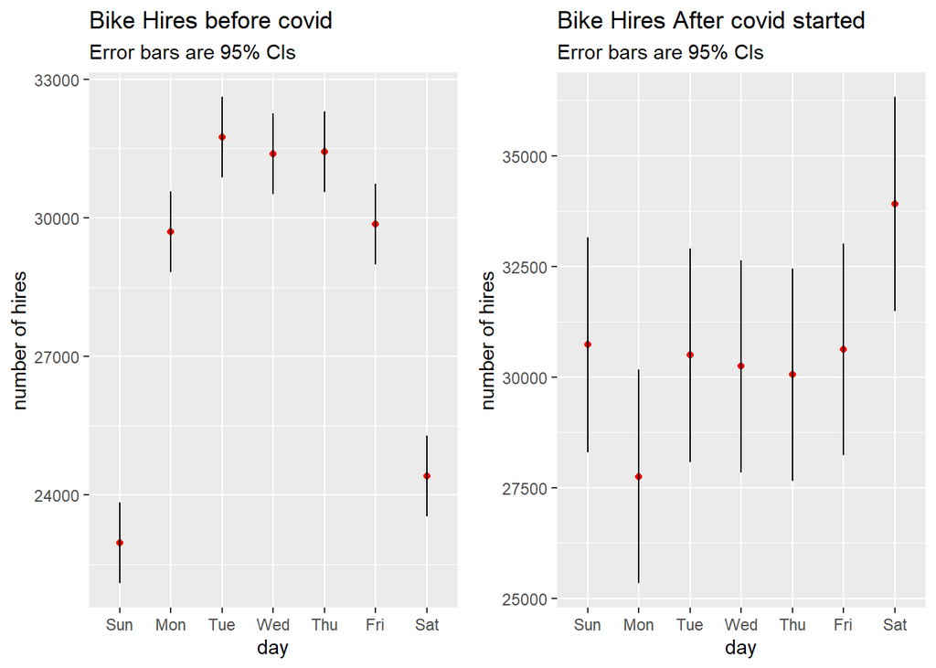

```r
dataset_emm_post_covid_days <- emmeans(hire_lm_postcovid,~.factor(day))
confint_hires_days_postcovid<-confint(pairs(dataset_emm_post_covid_days))

days_after_covid<-ggplot(summary(dataset_emm_post_covid_days), aes(x=day, y=emmean, ymin=lower.CL, ymax=upper.CL)) +
        geom_point(color="red") + geom_linerange() +
        labs(y="number of hires", x="day", subtitle="Error bars are 95% CIs", title="Bike Hires After covid started ")
grid.arrange(days_before_covid,days_after_covid,ncol=2)
```

#### Visualizing Month-wise bike hires before and after COVID-19 separately

```r
emmvar_pre <-  emmeans(hire_lm_precovid,~.factor(month))
contrast_pre<-confint(pairs(emmvar_pre))
 months_pre_covid<-ggplot(summary(emmvar_pre), aes(x=factor(month), y=emmean, ymin=lower.CL, ymax=upper.CL)) +
        geom_point(color="red") + geom_linerange() +
        labs(y="number of hires", x="month", subtitle="Error bars are 95% CIs", title="Pre covid trend for bike hire")
```

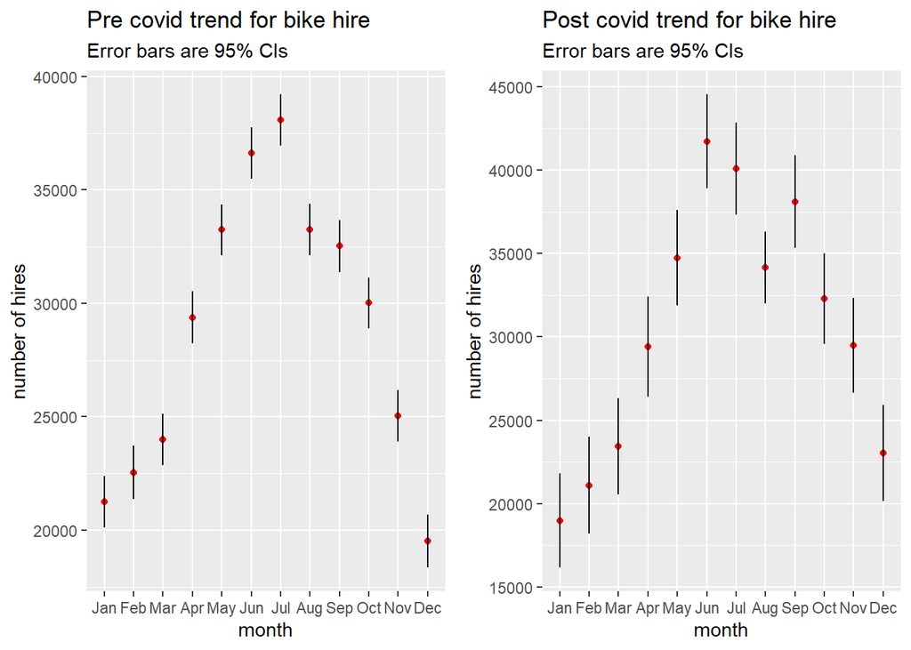

```r
emmvar_post <-  emmeans(hire_lm_postcovid,~.factor(month))
contrast_post<-confint(pairs(emmvar_post))
 months_post_covid<-ggplot(summary(emmvar_post), aes(x=factor(month), y=emmean, ymin=lower.CL, ymax=upper.CL)) +
        geom_point(color="red") + geom_linerange() +
        labs(y="number of hires", x="month", subtitle="Error bars are 95% CIs", title="Post covid trend for bike hire")
 grid.arrange(months_pre_covid,months_post_covid,ncol=2)
```

## Conclusion

- We need to control the effect of the wfh , eat_out_to_help_out and rule_of_six_indoor because there were impacting our number of hires after the covid measures were introduced.
- Also the effect of months and days were changed after the covid measures were introduced but for of years the trend become normal so there is not sufficient need to control

# Question 2

| Variable | Description |
| --- | --- |
| sold.by | seller through which the book got sold |
| publisher.type | Publisher who published the book |
| genre | genre of the book |
| avg.review | Average review scores of the book |
| daily.sales | Average number of sales across all days |
| total.reviews | Total number of reviews |
| sale.price | Average price for which the book |

## Objectives

### * Understand Sales Distribution

### * Analyze the Impact of Average Review Scores

### * Evaluate the Influence of Total Number of Reviews

### * Assess the Effect of Sale Price on Sales

### * Differentiate Sales Patterns Across Genres

## Data Preprocessing

```r
#Loading dataset
dataset_publisher<-read.csv("publisher_sales.csv",stringsAsFactor=TRUE)
```

```r
#checking data
str(dataset_publisher)
```

```
## 'data.frame':    6000 obs. of  7 variables:
##  $ sold.by       : Factor w/ 13 levels "Amazon Digital Services,  Inc.",..: 1 6 1 1 1 1 11 13 1 13 ...
##  $ publisher.type: Factor w/ 5 levels "amazon","big five",..: 3 2 5 5 5 5 2 2 5 2 ...
##  $ genre         : Factor w/ 3 levels "adult_fiction",..: 1 3 1 3 3 1 2 2 2 2 ...
##  $ avg.review    : num  4.5 4.64 2.5 4.5 4.98 3.98 4.62 3.5 4.64 4.56 ...
##  $ daily.sales   : num  84.4 113.1 70.8 149.4 135.7 ...
##  $ total.reviews : int  151 184 125 225 194 123 130 110 129 119 ...
##  $ sale.price    : num  5.12 6.91 6.27 4.91 7.39 ...
```

```r
summary(dataset_publisher)
```

```
##                                  sold.by           publisher.type
##  Amazon Digital Services,  Inc.      :4271   amazon       :  92
##  Random House LLC                    : 486   big five     :1688
##  Penguin Group (USA) LLC             : 346   indie        :1243
##  HarperCollins Publishers            : 274   single author: 789
##  Simon and Schuster Digital Sales Inc: 241   small/medium :2188
##  Macmillan                           : 172
##  (Other)                             : 210
##            genre        avg.review     daily.sales     total.reviews
##  adult_fiction:2000   Min.   :0.000   Min.   : -0.53   Min.   :  0.0
##  non_fiction  :2000   1st Qu.:4.090   1st Qu.: 64.22   1st Qu.:104.0
##  YA_fiction   :2000   Median :4.410   Median : 81.59   Median :128.0
##                       Mean   :4.269   Mean   : 86.37   Mean   :132.7
##                       3rd Qu.:4.610   3rd Qu.:104.73   3rd Qu.:163.0
##                       Max.   :4.980   Max.   :209.34   Max.   :243.0
##
##    sale.price
##  Min.   : 1.17
##  1st Qu.: 7.34
##  Median : 9.31
##  Mean   :10.30
##  3rd Qu.:13.58
##  Max.   :22.00
##
```

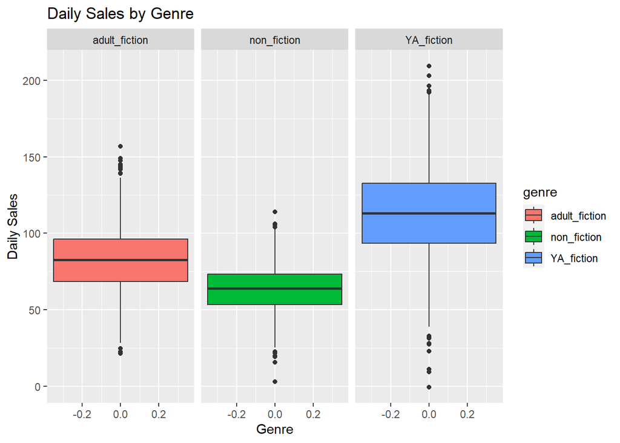

```r
# Plotting The data
ggplot(dataset_publisher) + geom_boxplot(width=0.7,aes(y = daily.sales,fill=genre)) +facet_wrap(genre~.) +labs(title = "Daily Sales by Genre", x = "Genre", y = "Daily Sales")
```